# KCRUG: Obtaining, wrangling, and mapping U.S. Census data using tidycensus

David W. Body

June 11, 2022

## Introduction

- David W. Body ([@david_body](https://twitter.com/david_body) on Twitter)
- Independent software developer and consultant ([Big Creek Software, LLC](https://www.bigcreek.com/))
- Currently working primarily on a machine learning project with video data
- Casual user of Census data – Not an expert!
- Agreed to give this talk to give myself an incentive to finish reading Kyle Walker’s book.

## Outline

Today we will cover

- How US Census data is organized
- Obtaining the data you want
- Wrangling the data
- Visualizing the data
  - Plots
  - Choropleth maps

## Some relevant R packages

- crsuggest
- [mapboxapi](https://walker-data.com/mapboxapi/)
- [**tidycensus**](https://walker-data.com/tidycensus/)
- tigris
- [mapview](https://r-spatial.github.io/mapview/)
- [sf](https://r-spatial.github.io/sf/)
- [**tidyverse**](https://www.tidyverse.org/)

The first 4 are by Kyle Walker.

## Analyzing US Census Data: Methods, Maps, and Models in R

by Kyle Walker

[figure not shown]

Available free online: https://walker-data.com/census-r/

Hard copy available for pre-order from CRC Press.

## Census API key

To use `tidycensus`, you will need a Census API key, which you can get for free from http://api.census.gov/data/key_signup.html.

Run the following once to install your key in your `.Renviron` file so it will automatically be available for future sessions.

```r
library(tidycensus)
census_api_key("YOUR KEY GOES HERE", install = TRUE)
```

## How is US Census data organized?

US Census data is organized by

- Datasets
- Variables
- Geographies

Today we will use just two datasets, but many more are available.

- 2020 Decennial Census
- 2016-2020 American Community Survey

## Decennial Census

The 2020 Decennial Census is supposed to be an *enumeration* of the whole US population. It collects a limited number of variables on race, ethnicity, age, sex, and housing tenure.

**Note**

The limited data currently available was released under [P.L. 94-171](https://www.census.gov/programs-surveys/decennial-census/about/rdo/summary-files.html) for political redistricting purposes.

## American Community Survey

- ACS is sent to about 3.5 million households per year
- Asks many more questions, including about income, education, language, and much more.
- ACS data are *estimates*. The uncertainty in these estimates is expressed as *margins of error* for each variable.

**Note**

The ACS had a lower than usual response rate in 2020 due to the COVID-19 pandemic. As a result of the smaller sample size, the margins of error are larger for 2020 data.

## Geographies and variables

Census datasets are broken down into

- Geographies
- Variables

## Census Geographies

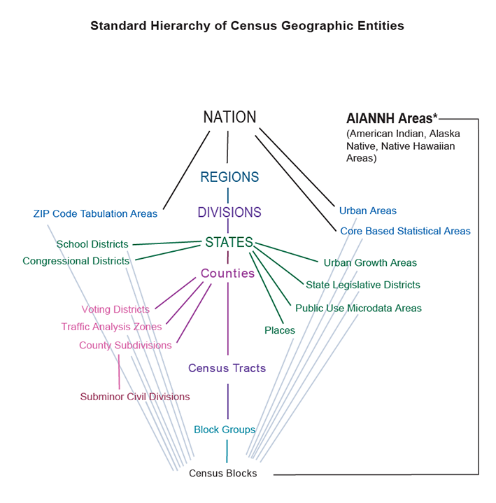

US Census Geographies, Source: US Census

## Census variables

- Different census datasets have different variables
- 2020 Decennial Census currently has relatively few variables (~300)
  - More variables will be released in the future
  - Example: **P1_001N** = Total population
- 2016-2020 ACS has around 28,000 variables
  - Example: **B15002_016** = Number of males with a master’s degree in the population age 25 and over

## Demo

- Manual workflow
  - data.census.gov
  - [TIGER/Line Shapefiles](https://www.census.gov/geographies/mapping-files/time-series/geo/tiger-line-file.html)
- Tidycensus code examples

## Other Resources

An independent project to make it easier for journalists to use ACS data:

- [Census Reporter](https://censusreporter.org/)

Recent workshops at the University of Michigan:

- [Analyzing 2020 Census data with R and tidycensus - YouTube](https://www.youtube.com/watch?v=u2m90iPOPto)
- [Making Maps of 2020 US Census Data in R - YouTube](https://www.youtube.com/watch?v=KMOTZij9qhU)
- [Using the New 2016-20 American Community Survey Estimates in R - YouTube](https://www.youtube.com/watch?v=hJ8OycTvQXM)